# Protocol 2

Joachim Goedhart

2021-12-16

## Protocol 2 - A superplot of calcium concentrations

This protocol is used to create a superplot which differentiates between technical and biological replicates. The concept of superplots has been reported by Lord and colleagues [(Lord et al., 2021)](https://doi.org/10.1083/jcb.202001064). We will use the data from a publication by [van der Linden et al. (2021)](https://doi.org/10.1038/s41467-021-27249-w) which was used to create figure 5e.

The original figure summarizes the data from all experiments and does not identify the biological replicates. Below, we will differentiate the biological replicates, by treating each batch of neutrophils as a biological replicate.

We start by loading the required tidyverse package:

```r
library(tidyverse)
```

We define the confidence level as 95%:

```r
Confidence_level <-  0.95
```

The data is stored in an excel sheet and we read it, skipping the first 6 lines which contain comments:

```r
df <- readxl::read_excel('figure5.xlsx', skip=6)
```

Let’s look at the data:

```r
head(df)
```

```
## # A tibble: 6 x 7
##   `Experimental day` `Replicate no.` `Neutrophil no.` `Batch no. neutroph… Stage `dF/F0`          `Calcium (uM)`
##                <dbl>           <dbl>            <dbl>                <dbl> <chr> <chr>                     <dbl>
## 1                  1               1                1                    1 befo… 9.2163432424556…         0.0488
## 2                  1               1                1                    1 befo… -1.419702139413…         0.0353
## 3                  1               1                1                    1 befo… 4.9806781516745…         0.0517
## 4                  1               1                1                    1 befo… 7.5848029984870…         0.0512
## 5                  1               1                1                    1 befo… 1.3300337728165…         0.0402
## 6                  1               1                1                    1 befo… 5.1152637484452…         0.0355
```

The data is already in a tidy format. The column with ‘Stage’ has the four different conditions for which we will compare the data in the column ‘Calcium (uM)’. We change the name of the column ‘Batch no. neutrophils’ to ‘Replicate’ and make sure the different replicates are treated as factors (qualitative data):

```r
df <- df %>% mutate(Replicate = as.factor(`Batch no. neutrophils`))
```

We define a new data frame with the summary statistics for individual biological replicates, i.e. by grouping the data for the different stages and biological replicates:

```r
df_summary <- df %>% group_by(Stage, Replicate) %>%
  summarise(n=n(), mean=mean(`Calcium (uM)`))
```

Next, we use ‘df_summary’ which holds the averages of each biological replicate, and we calculate the statistics for the different conditions:

```r
df_summary_replicas <- df_summary %>% group_by(Stage) %>%
  summarise(n=n(), mean_rep=mean(mean), sd_rep = sd(mean))  %>%
  mutate(sem = sd_rep / sqrt(n - 1),
         `95%CI_lo` = mean_rep + qt((1-Confidence_level)/2, n - 1) * sem,
         `95%CI_hi` = mean_rep - qt((1-Confidence_level)/2, n - 1) * sem,
         NULL)
```

The dataframe has the summary of the conditions and note that each condition has a summary of 4 biological replicates:

```r
head(df_summary_replicas)
```

```
## # A tibble: 4 x 7
##   Stage               n mean_rep  sd_rep     sem `95%CI_lo` `95%CI_hi`
##   <chr>           <int>    <dbl>   <dbl>   <dbl>      <dbl>      <dbl>
## 1 before              4   0.0301 0.00414 0.00239     0.0225     0.0377
## 2 crawling            4   0.0317 0.00339 0.00196     0.0255     0.0380
## 3 diapedesis          4   0.0309 0.00861 0.00497     0.0151     0.0467
## 4 post-diapedesis     4   0.0345 0.00551 0.00318     0.0244     0.0447
```

Let’s first define a basic plot with all of the data for each stage shown as a violinplot:

```r
p <- ggplot(data=df, aes(x=Stage)) +
  geom_violin(data=df, aes(x=Stage, y=`Calcium (uM)`), color=NA, fill="grey80")
```

This is what it looks like:

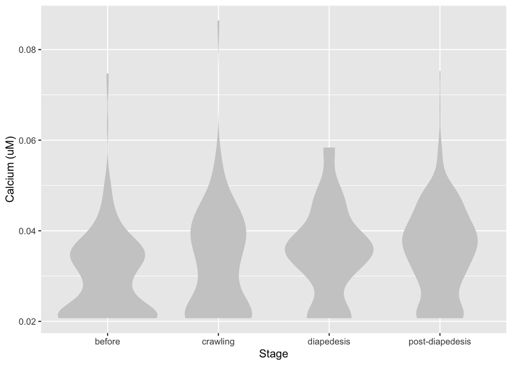

```r
p
```

We add the 95% confidence interval from the summary of the biological replicates as a line:

```r
 p <- p + geom_linerange(data = df_summary_replicas, aes(ymin=`95%CI_lo`, ymax=`95%CI_hi`), size=1, alpha=0.8)
```

And we add the mean value of each replicate as a dot. Here, the size of the dot is reflecting n:

```r
p <- p + geom_point(data=df_summary, aes(x=Stage, y=mean, size=n, fill=Replicate),  shape=21, stroke = 1)
```

The function `scale_size_area()` ensures that 0 is represented as an area of 0 and allows to to define that an n of 10,50 and 90 is shown in the legend:

```r
p <- p + scale_size_area(breaks = c(10, 50, 90), max_size = 6)
```

This is what that looks like:

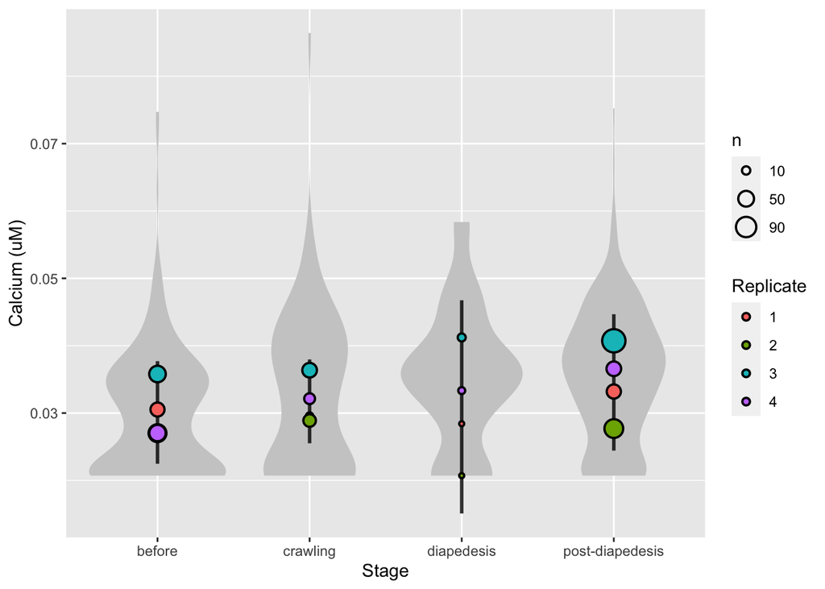

```r
p
```

Next, one of my favorite tweaks for discrete conditions is to rotate the plot 90 degrees. At the same time, the limits are defined.

```r
p <- p + coord_flip(ylim = c(0.02,0.09)) +
  # This ensures correct order of conditions when plot is rotated 90 degrees
  scale_x_discrete(limits = rev)
```

Rotation improves readability of the labels for the conditions, even when they are long. It also easier to read the different calcium levels:

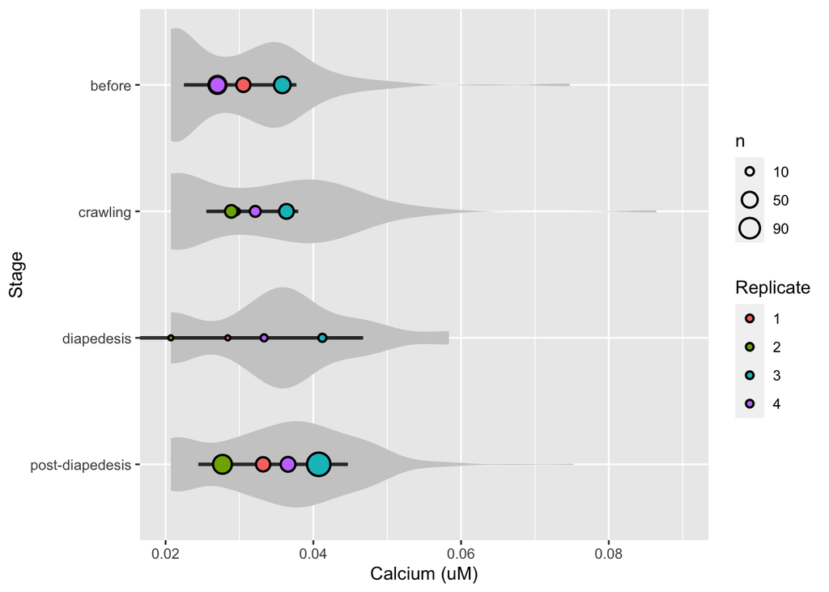

```r
p
```

To guide the interpretation, a line is added as a threshold of 0.06 µM (=60 nM):

```r
p <- p + geom_hline(yintercept = 0.060, linetype='dotted')
```

Adjusting the axis labels and adding a title and caption:

```r
p <-
  p + labs(
    title = "Calcium concentrations are less than 60 nM",
    subtitle = "at different stages of transendothelial migration",
    x = "Stage",
    y = "Calcium [µM]",
    caption = "(based on data from van der Linden, DOI: 10.1101/2021.06.21.449214)",
    tag = "Protocol 2"
  )
```

The layout it further optimized. The most tricky part is positioning of the label for the different conditions. It is placed right above the conditions, which I really like. However, getting this right involves a bit of trial and error and I recommend playing with the parameters to see how it affects the positioning. Something similar applies to the legend which is moved into the lower right corner of the plot, although this is eassier to accomplish. The comments explain the effect of the different lines:

```r
p <-
  #Set text size
  p + theme_classic(base_size = 16) + theme(
    plot.caption = element_text(
      color = "grey80",
      hjust = 1
    ),
    #Set position of legend to lower right corner
    legend.position = c(0.88,0.15),

    #This line positions the label ('title') of the conditions
    axis.title.y = element_text(vjust = 0.98, angle = 0, margin=margin(l=70)),

    #This line positions the names of the conditions
    #A negative margin is needed for aligning the y-axis 'title' with the 'text'
    axis.text.y = element_text(vjust = 0.5, hjust=1, angle = 0, margin=margin(l=-90, r=5)),

    #Move 'tag', so its position partially overlaps with the conditions
    plot.tag.position = c(0.06,0.99)
    ) + guides(fill = "none",
               size = guide_legend(title = 'n per replicate', label.position = "left")
               )
```

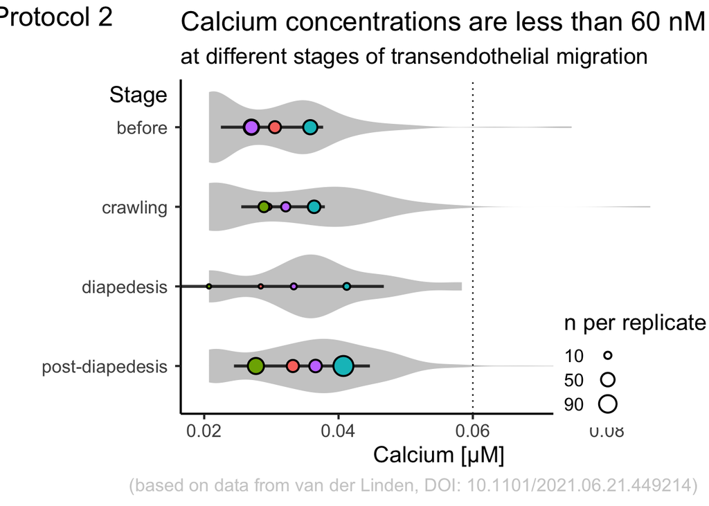

```r
p
```

To save the plot as a PNG file:

```r
png(file=paste0("Protocol_2.png"), width = 4000, height = 3000, units = "px", res = 400)
  p
dev.off()
```